[Voltar](https://brunopiato.github.io/R/)

# Relatório Biologia Evolutiva e Estatística

## Médias, variância e coeficientes de covariação

Antes de mais nada podemos calcular as médias, variâncias e coeficientes de variação para cada traço de cada uma das espécies, bem como estatísticas descritivas globais.

```
## $media
##   especie   humerus      ulna    femur    tibia
## 1       A  4.948718  9.949203 15.11119 20.17994
## 2       B  8.449116 17.043157 25.58400 34.03991
## 3       C 10.086848 20.234410 21.54564 28.41128
## 4       D 10.764505 21.917249 27.70168 37.03902
## 5       E  7.396516 14.408397 20.55298 27.52810
##
## $desv_pad
##   especie   humerus      ulna     femur     tibia
## 1       A 0.9254339 1.0422595 1.0019777 1.0333496
## 2       B 1.0435816 0.9763112 0.9598005 1.0262900
## 3       C 0.9928206 0.9678160 1.0932851 0.9548355
## 4       D 0.9973459 0.9990719 1.0923769 0.9549701
## 5       E 0.9848018 0.8007156 0.9546276 1.0020572
##
## $vari
##   especie   humerus      ulna     femur     tibia
## 1       A 0.8564279 1.0863048 1.0039593 1.0678113
## 2       B 1.0890625 0.9531835 0.9212171 1.0532711
## 3       C 0.9856927 0.9366678 1.1952724 0.9117107
## 4       D 0.9946989 0.9981447 1.1932873 0.9119679
## 5       E 0.9698346 0.6411455 0.9113138 1.0041185
##
## $coef_var
##   especie    humerus       ulna      femur      tibia
## 1       A 0.18700477 0.10475809 0.06630699 0.05120677
## 2       B 0.12351370 0.05728464 0.03751566 0.03014961
## 3       C 0.09842724 0.04783021 0.05074276 0.03360762
## 4       D 0.09265135 0.04558382 0.03943360 0.02578281
## 5       E 0.13314401 0.05557284 0.04644716 0.03640125
```

## Matriz de variância/covariância e matrizes de correlação

Podemos, então calcular as matrizes de variância/covariância para cada uma das espécies. Com elas, podemos, ainda, calcular as matrizes de correlação entre os caracteres de cada espécie e, através disto, identificar módulos.

Var/covar

```
##
##  Espécie A
##           humerus      ulna     femur     tibia
## humerus 0.8564279 0.7757185 0.2162784 0.2754821
## ulna    0.7757185 1.0863048 0.3172945 0.3577048
## femur   0.2162784 0.3172945 1.0039593 0.7962791
## tibia   0.2754821 0.3577048 0.7962791 1.0678113
##
##  Espécie B
##           humerus       ulna      femur     tibia
## humerus 1.0890625 0.44145759 0.17321563 0.1971403
## ulna    0.4414576 0.95318347 0.03739387 0.1376643
## femur   0.1732156 0.03739387 0.92121709 0.6792800
## tibia   0.1971403 0.13766425 0.67928003 1.0532711
##
##  Espécie C
##            humerus       ulna      femur     tibia
## humerus 0.98569270 0.75790946 0.01627433 0.3289341
## ulna    0.75790946 0.93666780 0.08537023 0.3363819
## femur   0.01627433 0.08537023 1.19527238 0.1735237
## tibia   0.32893410 0.33638186 0.17352372 0.9117107
##
##  Espécie D
##           humerus      ulna     femur     tibia
## humerus 0.9946989 0.7761668 0.5626162 0.5584096
## ulna    0.7761668 0.9981447 0.7903109 0.6367767
## femur   0.5626162 0.7903109 1.1932873 0.6057237
## tibia   0.5584096 0.6367767 0.6057237 0.9119679
##
##  Espécie E
##             humerus        ulna      femur     tibia
## humerus  0.96983460 -0.09642127 0.02096006 0.3606990
## ulna    -0.09642127  0.64114545 0.01036461 0.1279602
## femur    0.02096006  0.01036461 0.91131380 0.2485472
## tibia    0.36069899  0.12796018 0.24854724 1.0041185
```

Corr

```
##
##  Espécie A
##           humerus      ulna     femur     tibia
## humerus 1.0000000 0.8042349 0.2332436 0.2880717
## ulna    0.8042349 1.0000000 0.3038286 0.3321251
## femur   0.2332436 0.3038286 1.0000000 0.7690596
## tibia   0.2880717 0.3321251 0.7690596 1.0000000
##
##  Espécie B
##           humerus       ulna      femur     tibia
## humerus 1.0000000 0.43328569 0.17293372 0.1840682
## ulna    0.4332857 1.00000000 0.03990535 0.1373924
## femur   0.1729337 0.03990535 1.00000000 0.6896008
## tibia   0.1840682 0.13739244 0.68960082 1.0000000
##
##  Espécie C
##            humerus       ulna      femur     tibia
## humerus 1.00000000 0.78877614 0.01499336 0.3469841
## ulna    0.78877614 1.00000000 0.08068266 0.3640083
## femur   0.01499336 0.08068266 1.00000000 0.1662252
## tibia   0.34698412 0.36400826 0.16622521 1.0000000
##
##  Espécie D
##           humerus      ulna     femur     tibia
## humerus 1.0000000 0.7789553 0.5164091 0.5862964
## ulna    0.7789553 1.0000000 0.7241503 0.6674222
## femur   0.5164091 0.7241503 1.0000000 0.5806471
## tibia   0.5862964 0.6674222 0.5806471 1.0000000
##
##  Espécie E
##             humerus        ulna      femur     tibia
## humerus  1.00000000 -0.12227727 0.02229512 0.3655136
## ulna    -0.12227727  1.00000000 0.01355941 0.1594792
## femur    0.02229512  0.01355941 1.00000000 0.2598259
## tibia    0.36551364  0.15947920 0.25982593 1.0000000
```

Para facilitar a visualização das correlações entre os traços vamos colorir as matrizes de correlação de acordo com a força da correlação entre eles.

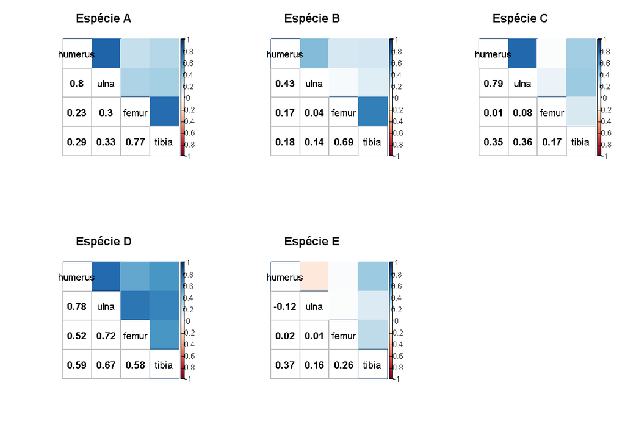

Com isso podemos ver claramente que a espécie A tem um padrão de modularidade entre úmero e ulna e entre tíbia e fêmur, formando um módulo dos membros anteriores e um módulo dos membros posteriores. A espécie B, embora apresente um padrão de modularidade similar, sua magnitude de integração é muito menor, fazendo com que a correlação entre os traços de cada módulo seja menor. A espécie C, por sua vez, apresenta o módulo membros anteriores, mas não o módulo membros posteriores. A espécie D apresenta grande correlação entre todos os traços, evidenciando a formação de um único módulo, enquanto a espécie E não apresenta correlação forte entre nenhum par de traços, evidenciando a ausência de integração entre os traços de seu corpo.